# Lab 05/ Grupo 01

Fecha de entrega: 07/07/2021

Oscar Agüero, M del Carmen Carranza, Jesús Guzmán, Ricardo Zamora

## Instrucciones generales

Genere un `R Markdown` en donde se muestre el código utilizado y la salida de este.

### PREGUNTA 1: bootstrap

Vamos a construir distintos intervalos de confianza maeidante *bootstrap* y revisar su covertura para diferentes tamaños de muestra en un estudio de simulación

Primero, estimamos el promedio truncado $\theta$ de la distribución Gamma $\Gamma(2,2)$ cuando el 10% superior y 10% inferior de las observcaiones se descartan. Aproximaremos $\theta$ con base en una muestra *grande*.

```r
set.seed(1)
(th <- mean(rgamma(1e8, shape = 2, rate = 2), trim = 0.1))
```

```
## [1] 0.9105642
```

Ahora, construimos una muestra de 40 elementos de la distribución $\Gamma(2,2)$ y estimamos $\theta$ mediante el promedio truncado $\hat{\theta}$ de la muestra.

```r
x40 <- rgamma(40, shape = 2, rate = 2)
th.h <- mean(x40, trim = 0.1)
```

**A.**

- **Cuantil:**

$$[q_{\hat{\theta^*}}(\alpha/2),q_{\hat{\theta^*}}(1-\alpha/2)]$$

- **Aproximación normal:**

$$2\hat{\theta} - \bar{\hat{\theta}^*} \pm q_{Z}(1-\alpha/2) \cdot \widehat{\text{sd}}(\hat{\theta})$$

donde $Z \sim \mathcal{N}(0,1)$ y $\widehat{\text{sd}}(\hat{\theta}) = \sqrt{\frac{1}{R-1}}\sum_{i=1}^{R}\left( \hat{\theta}^{*i}- \bar{\hat{\theta}^*} \right)^2$.

- **Cuantil inverso:**

$$[\hat{\theta}-q_{\hat{\theta}^*-\hat{\theta}}(1-\alpha/2), \hat{\theta}-q_{\hat{\theta}^*-\hat{\theta}}(\alpha/2)].$$

**Hint:** si quisieran utilizar el paquete `boot`, `'type = "perc"` corresponde con el tipo *cuantil*, `type = "norm"` corresponde con la *aproximación normal* y `type = "basic"` corresponde al *cuantil inverso*.

```r
library(boot)
muestra1 <- boot(data=data.frame(x40),
            statistic=function(d,i) return(mean(d[i,], trim = 0.1)),
            R = 10000,sim="ordinary",stype="i")
            boot.ci(muestra1, conf = 0.90,type = c("perc","norm", "basic"))
```

```
## BOOTSTRAP CONFIDENCE INTERVAL CALCULATIONS
## Based on 10000 bootstrap replicates
##
## CALL :
## boot.ci(boot.out = muestra1, conf = 0.9, type = c("perc", "norm",
##     "basic"))
##
## Intervals :
## Level      Normal              Basic              Percentile
## 90%   ( 0.6690,  1.0826 )   ( 0.6521,  1.0639 )   ( 0.7029,  1.1147 )
## Calculations and Intervals on Original Scale
```

**B.**

Simular 200 nuevos juegos de datos (de 10,40,160 y 640 observaciones cada uno) y construir diferentes intervalos de confianza con base en 500 muestras-bootstrap. Para cada tipo de intervalo de confianza, calcular el porcentaje de intervalos de confianza que no contienen el valor real $\theta$. Específicamente, si el intervalo de confianza se denota como $[\text{CI}_l, \text{CI}_u]$, calcular

- el porcentaje de veces que $\theta \notin [\text{CI}_l, \text{CI}_u]$,
- el porcentaje de veces que $\theta < \text{CI}_l$, y
- el porcentaje de veces que $\theta > \text{CI}_u$.

y mostrar los resultados en forma gráfica.

```r
library(purrr)
library(ggplot2)

n1 <- 10
n2 <- 40
n3 <- 160
n4 <- 640

obs_10<- map(.x=1:200,.f=function(.x) rgamma(n1, shape = 2, rate = 2))

obs_40<- map(.x=1:200,.f=function(.x) rgamma(n2, shape = 2, rate = 2))

obs_160<- map(.x=1:200,.f=function(.x) rgamma(n3, shape = 2, rate = 2))

obs_640<- map(.x=1:200,.f=function(.x) rgamma(n4, shape = 2, rate = 2))


obs_10<- lapply(X=obs_10,FUN= function(x){boot(data=x,
                              statistic=function(d,i) return(mean(d[i], trim = 0.1)),
                              R = 500,sim="ordinary",stype="i")})

obs_10<- lapply(X=obs_10,FUN=function(x) { I1<- boot.ci(x, conf = 0.95,
                          type = c("perc","norm", "basic"))
return(list(c(I1[["normal"]][2:3],I1[["basic"]][4:5],I1[["percent"]][4:5])))
})

obs_10 <- t(do.call(cbind.data.frame, obs_10))



obs_40<- lapply(X=obs_40,FUN= function(x){boot(data=x,
                                                 statistic=function(d,i) return(mean(d[i], trim = 0.1)),
                                                 R = 500,sim="ordinary",stype="i")})

obs_40<- lapply(X=obs_40,FUN=function(x) { I1<- boot.ci(x, conf = 0.95,
                                                    type = c("perc","norm", "basic"))
return(list(c(I1[["normal"]][2:3],I1[["basic"]][4:5],I1[["percent"]][4:5])))
})

obs_40 <- t(do.call(cbind.data.frame, obs_40))


obs_160<- lapply(X=obs_160,FUN= function(x){boot(data=x,
                                                 statistic=function(d,i) return(mean(d[i], trim = 0.1)),
                                                 R = 500,sim="ordinary",stype="i")})

obs_160<- lapply(X=obs_160,FUN=function(x) { I1<- boot.ci(x, conf = 0.95,
                                                    type = c("perc","norm", "basic"))
return(list(c(I1[["normal"]][2:3],I1[["basic"]][4:5],I1[["percent"]][4:5])))
})

obs_160 <- t(do.call(cbind.data.frame, obs_160))


obs_640<- lapply(X=obs_640,FUN= function(x){boot(data=x,
                                                   statistic=function(d,i) return(mean(d[i], trim = 0.1)),
                                                   R = 500,sim="ordinary",stype="i")})

obs_640<- lapply(X=obs_640,FUN=function(x) { I1<- boot.ci(x, conf = 0.95,
                                                      type = c("perc","norm", "basic"))
return(list(c(I1[["normal"]][2:3],I1[["basic"]][4:5],I1[["percent"]][4:5])))
})

obs_640 <- t(do.call(cbind.data.frame, obs_640))


obs_10<- as.data.frame(cbind(obs_10,1:200,th))
obs_40<- as.data.frame(cbind(obs_40,1:200,th))
obs_160<- as.data.frame(cbind(obs_160,1:200,th))
obs_640<- as.data.frame(cbind(obs_640,1:200,th))

names(obs_10) <- c("I.I.Aproximación normal","I.S.Aproximación normal","I.I.Cuantil inverso",
                 "I.S.Cuantil inverso","I.I.Cuantil","I.S.Cuantil","Muestra","Parámetro")

names(obs_40) <- c("I.I.Aproximación normal","I.S.Aproximación normal","I.I.Cuantil inverso",
                 "I.S.Cuantil inverso","I.I.Cuantil","I.S.Cuantil","Muestra","Parámetro")

names(obs_160) <- c("I.I.Aproximación normal","I.S.Aproximación normal","I.I.Cuantil inverso",
                 "I.S.Cuantil inverso","I.I.Cuantil","I.S.Cuantil","Muestra","Parámetro")

names(obs_640) <- c("I.I.Aproximación normal","I.S.Aproximación normal","I.I.Cuantil inverso",
                 "I.S.Cuantil inverso","I.I.Cuantil","I.S.Cuantil","Muestra","Parámetro")


##########################################################################################################
########################################## PARA 10 OBSERVACIONES #########################################
##########################################################################################################

grafico <- cbind.data.frame("I.I>Parametro"=prop.table(table(obs_10$`I.I.Aproximación normal`>obs_10$Parámetro))[2]*100,
                            "I.S<Parametro"=prop.table(table(obs_10$`I.S.Aproximación normal`<obs_10$Parámetro))[2]*100,
                            "I.no.contienten.parametro"=prop.table(table((obs_10$`I.S.Aproximación normal`<obs_10$Parámetro)|(obs_10$`I.I.Aproximación normal`>obs_10$Parámetro)))[2]*100
)

grafico <- rbind.data.frame(grafico,cbind.data.frame("I.I>Parametro"=prop.table(table(obs_10$`I.I.Cuantil inverso`>obs_10$Parámetro))[2]*100,
                            "I.S<Parametro"=prop.table(table(obs_10$`I.S.Cuantil inverso`<obs_10$Parámetro))[2]*100,
                            "I.no.contienten.parametro"=prop.table(table((obs_10$`I.S.Cuantil inverso`<obs_10$Parámetro)|(obs_10$`I.I.Cuantil inverso`>obs_10$Parámetro)))[2]*100

)
)

grafico <- rbind.data.frame(grafico,cbind.data.frame("I.I>Parametro"=prop.table(table(obs_10$`I.I.Cuantil`>obs_10$Parámetro))[2]*100,
                                                     "I.S<Parametro"=prop.table(table(obs_10$`I.S.Cuantil`<obs_10$Parámetro))[2]*100,
                                                     "I.no.contienten.parametro"=prop.table(table((obs_10$`I.S.Cuantil`<obs_10$Parámetro)|(obs_10$`I.I.Cuantil`>obs_10$Parámetro)))[2]*100


)
)



##########################################################################################################
########################################## PARA 40 OBSERVACIONES #########################################
##########################################################################################################

grafico <- rbind.data.frame(grafico,cbind.data.frame("I.I>Parametro"=prop.table(table(obs_40$`I.I.Aproximación normal`>obs_40$Parámetro))[2]*100,
                                                     "I.S<Parametro"=prop.table(table(obs_40$`I.S.Aproximación normal`<obs_40$Parámetro))[2]*100,
                                                     "I.no.contienten.parametro"=prop.table(table((obs_40$`I.S.Aproximación normal`<obs_40$Parámetro)|(obs_40$`I.I.Aproximación normal`>obs_40$Parámetro)))[2]*100
)
)


grafico <- rbind.data.frame(grafico,cbind.data.frame("I.I>Parametro"=prop.table(table(obs_40$`I.I.Cuantil inverso`>obs_40$Parámetro))[2]*100,
                                                     "I.S<Parametro"=prop.table(table(obs_40$`I.S.Cuantil inverso`<obs_40$Parámetro))[2]*100,
                                                     "I.no.contienten.parametro"=prop.table(table((obs_40$`I.S.Cuantil inverso`<obs_40$Parámetro)|(obs_40$`I.I.Cuantil inverso`>obs_40$Parámetro)))[2]*100

)
)

grafico <- rbind.data.frame(grafico,cbind.data.frame("I.I>Parametro"=prop.table(table(obs_40$`I.I.Cuantil`>obs_40$Parámetro))[2]*100,
                                                     "I.S<Parametro"=prop.table(table(obs_40$`I.S.Cuantil`<obs_40$Parámetro))[2]*100,
                                                     "I.no.contienten.parametro"=prop.table(table((obs_40$`I.S.Cuantil`<obs_40$Parámetro)|(obs_40$`I.I.Cuantil`>obs_40$Parámetro)))[2]*100


)
)

##########################################################################################################
########################################## PARA 160 OBSERVACIONES ########################################
##########################################################################################################

grafico <- rbind.data.frame(grafico,cbind.data.frame("I.I>Parametro"=prop.table(table(obs_160$`I.I.Aproximación normal`>obs_160$Parámetro))[2]*100,
                                                     "I.S<Parametro"=prop.table(table(obs_160$`I.S.Aproximación normal`<obs_160$Parámetro))[2]*100,
                                                     "I.no.contienten.parametro"=prop.table(table((obs_160$`I.S.Aproximación normal`<obs_160$Parámetro)|(obs_160$`I.I.Aproximación normal`>obs_160$Parámetro)))[2]*100
)
)


grafico <- rbind.data.frame(grafico,cbind.data.frame("I.I>Parametro"=prop.table(table(obs_160$`I.I.Cuantil inverso`>obs_160$Parámetro))[2]*100,
                                                     "I.S<Parametro"=prop.table(table(obs_160$`I.S.Cuantil inverso`<obs_160$Parámetro))[2]*100,
                                                     "I.no.contienten.parametro"=prop.table(table((obs_160$`I.S.Cuantil inverso`<obs_160$Parámetro)|(obs_160$`I.I.Cuantil inverso`>obs_160$Parámetro)))[2]*100

)
)

grafico <- rbind.data.frame(grafico,cbind.data.frame("I.I>Parametro"=prop.table(table(obs_160$`I.I.Cuantil`>obs_160$Parámetro))[2]*100,
                                                     "I.S<Parametro"=prop.table(table(obs_160$`I.S.Cuantil`<obs_160$Parámetro))[2]*100,
                                                     "I.no.contienten.parametro"=prop.table(table((obs_160$`I.S.Cuantil`<obs_160$Parámetro)|(obs_160$`I.I.Cuantil`>obs_160$Parámetro)))[2]*100


)
)
##########################################################################################################
########################################## PARA 640 OBSERVACIONES ########################################
##########################################################################################################


grafico <- rbind.data.frame(grafico,cbind.data.frame("I.I>Parametro"=prop.table(table(obs_640$`I.I.Aproximación normal`>obs_640$Parámetro))[2]*100,
                                                     "I.S<Parametro"=prop.table(table(obs_640$`I.S.Aproximación normal`<obs_640$Parámetro))[2]*100,
                                                     "I.no.contienten.parametro"=prop.table(table((obs_640$`I.S.Aproximación normal`<obs_640$Parámetro)|(obs_640$`I.I.Aproximación normal`>obs_640$Parámetro)))[2]*100
)
)


grafico <- rbind.data.frame(grafico,cbind.data.frame("I.I>Parametro"=prop.table(table(obs_640$`I.I.Cuantil inverso`>obs_640$Parámetro))[2]*100,
                                                     "I.S<Parametro"=prop.table(table(obs_640$`I.S.Cuantil inverso`<obs_640$Parámetro))[2]*100,
                                                     "I.no.contienten.parametro"=prop.table(table((obs_640$`I.S.Cuantil inverso`<obs_640$Parámetro)|(obs_640$`I.I.Cuantil inverso`>obs_640$Parámetro)))[2]*100

)
)

grafico <- rbind.data.frame(grafico,cbind.data.frame("I.I>Parametro"=prop.table(table(obs_640$`I.I.Cuantil`>obs_640$Parámetro))[2]*100,
                                                     "I.S<Parametro"=prop.table(table(obs_640$`I.S.Cuantil`<obs_640$Parámetro))[2]*100,
                                                     "I.no.contienten.parametro"=prop.table(table((obs_640$`I.S.Cuantil`<obs_640$Parámetro)|(obs_640$`I.I.Cuantil`>obs_640$Parámetro)))[2]*100
)
)
```

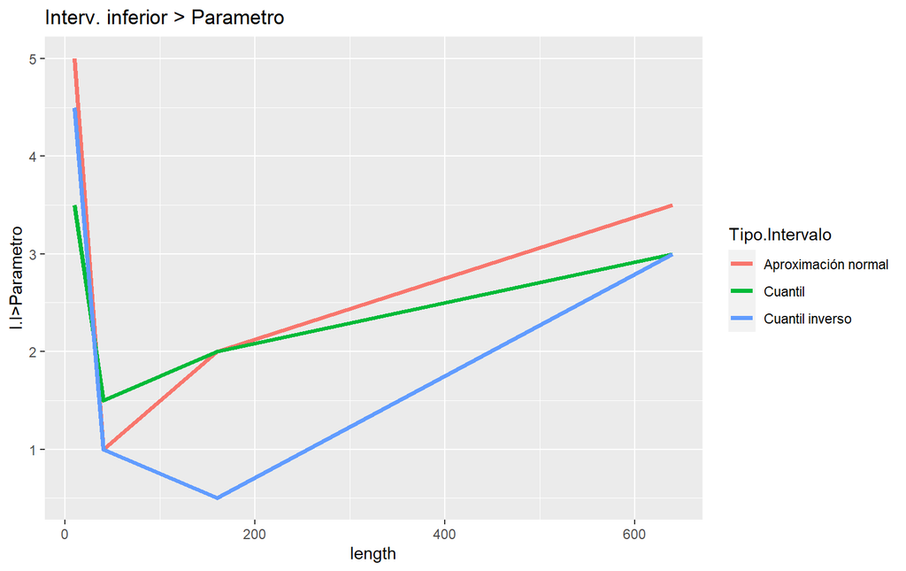

```r
grafico$length <- rep(c(n1,n2,n3,n4),times=1,each=3)

grafico$Tipo.Intervalo <- rep(c("Aproximación normal", "Cuantil inverso", "Cuantil"), times = 4, each = 1)

ggplot(grafico,aes(x = length, y = `I.I>Parametro`,
                   colour = Tipo.Intervalo)) + geom_line(size = 1.3) +
                   ggtitle("Interv. inferior > Parametro")
```

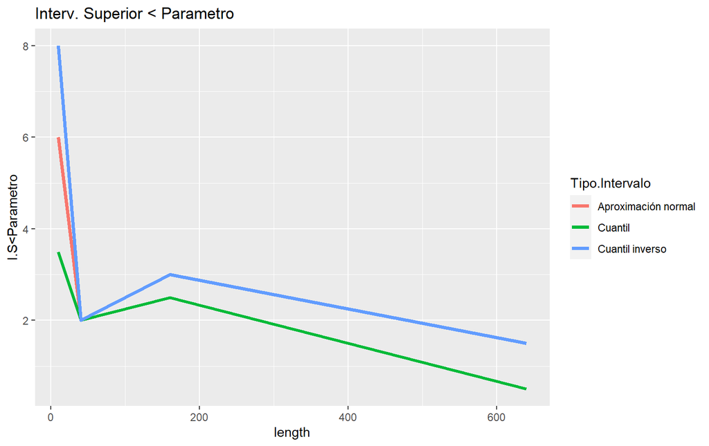

```r
ggplot(grafico,aes(x = length, y = `I.S<Parametro`,
                   colour = Tipo.Intervalo)) + geom_line(size = 1.3) +
                   ggtitle("Interv. Superior < Parametro")
```

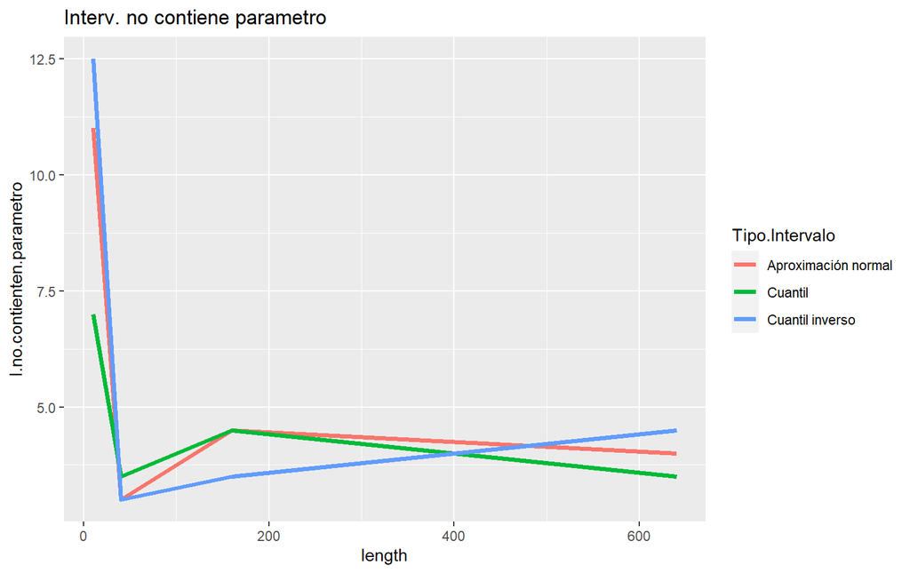

```r
ggplot(grafico,aes(x = length, y = `I.no.contienten.parametro`,
                   colour = Tipo.Intervalo)) + geom_line(size=1.3) +
                   ggtitle("Interv. no contiene parametro")
```

### PREGUNTA 2: bootstrap doble

En este ejercicio nos basaremos en la **PREGUNTA 1** pero aplicaremos una correción utilizando bootstrap doble. Estimamos, entonces, el promedio truncado $\theta$ de la distribución Gamma $\Gamma(2,2)$ donde dejamos por fuera el 10% superior e inferior de observaciones.

```r
set.seed(1)
(th <- mean(rgamma(1e8, shape = 2, rate = 2), trim = 0.1))
```

```
## [1] 0.9105642
```

Ahora, con base en una muestra de 40 observaciones estimamos $\hat{\theta}$ mediante un promedio truncado.

```r
x40 <- rgamma(40, shape = 2, rate = 2)
th.h <- mean(x40, trim = 0.1)
```

**A.**

Construir intervalos de confianza al 90% mediante bootstrap para el promedio truncado $\theta$ basados en `x40`. Los intervalos de confianza requeridos son

- **Cuantil inverso:**

$$[\hat{\theta}-q_{\hat{\theta}^*-\hat{\theta}}(1-\alpha/2), \hat{\theta}-q_{\hat{\theta}^*-\hat{\theta}}(\alpha/2)]$$

- **Cuantl inverso con corrección de nivel:**

$$[\hat{\theta}-q_{\hat{\theta}^*-\hat{\theta}}(1-\alpha^\prime/2), \hat{\theta}-q_{\hat{\theta}^*-\hat{\theta}}(\alpha^\prime/2)]$$

donde $\alpha^\prime$ es el nivel ajustado tal que tenemos una cobertura del 90% para $\hat{\theta}$ en la segunda capa del bootstrap.

Para el bootstrap doble, usamos $M=50$ muestras para el nivel exterior y $B=500$ para la segunda capa. Al final, se calculan los intervalos de confianza basados en $B=500$ muestra con un nivel nominal $\alpha$ (para el cuantil inverso) y $\alpha^\prime$ (para los intervalos corregidos por bootstrap doble).

```r
library(tidyverse)
# inserte acá su código
# numero de repeticiones en el primer nivel
M <-  500
# numero de repeticiones en el segundo nivel
B <- 1000

# Cuantil inverso con boostrap doble

r <- numeric(M)
set.seed(1)
for(i in 1:M){
  if(i %% 10 == 0) cat(".", if(i %% 500 == 0) sprintf(" %6d\n", i))
  ind <- sample.int(length(x40), replace = TRUE)
  x40_b <- x40[ind]
  r[i] <- mean(x40_b, trim = 0.1)
}
```

```
## ..................................................     500
```

```r
qtl_dif <- r-th.h
qtl_dif_val <- quantile(qtl_dif, c(0.05, 0.95))

# Intervalo del cuantil inverso

th.h-c(qtl_dif_val[2],qtl_dif_val[1])
```

```
##      95%       5%
## 0.655860 1.068431
```

```r
# Calcular el boostrap doble

cover1 <- numeric(M)
cover2 <- matrix(NA, nrow = M, ncol = B)

set.seed(1)
for(i in 1:M){
  ind <- sample.int(length(x40), replace = TRUE)
  x40_b <- x40[ind]
  cover1[i] <- mean(x40_b, trim = 0.1)
  for( j in 1:B){
    ind <- sample.int(length(x40_b), replace = TRUE)
    x40_b2 <- x40_b[ind]
    cover2[i,j] <- mean(x40_b2, trim = 0.1)
  }
}

# calculo de intervalos de confianza
diff2N <- matrix(0, nrow = M, ncol = B)

for(i in 1:M){
  for (j in 1:B) {
    diff2N[i,j]<- cover2[i,j]-cover1[i]
  }
}

a <- 0.10
q05 <- function( x ) quantile(x, a/2 )
q95 <- function( x ) quantile(x, 1-a/2)


qtl_dif_5 <- apply(diff2N, 1, q05)
qtl_dif_95 <- apply(diff2N, 1, q95)


IC_L <- cover1-qtl_dif_5
IC_H<- cover1-qtl_dif_95

# covertura

covertura <- numeric(M)

for ( i in 1:M) {
  covertura[i] <- ifelse(IC_L[i] < th.h & th.h < IC_H[i], 1, 0 )
}

covertura_prox <- sum(covertura)/M
covertura_prox
```

```
## [1] 0
```

```r
# Variando Alpha

q_low <- function(x,a) quantile(x, a/2 )
q_high <- function(x,a) quantile(x, 1-a/2)


bootdoble_aplha <- function(a, M, B, data, th.h){

  theta1N <- numeric(M)
  theta2N <- matrix(NA, nrow = M, ncol = B)

  set.seed(1)
  for(i in 1:M){
    ind <- sample.int(length(data), replace = TRUE)
    data_b <- data[ind]
    theta1N[i] <- mean(data_b, trim = 0.1)
    for( j in 1:B){
      ind <- sample.int(length(data_b), replace = TRUE)
      data_b2 <- data_b[ind]
      theta2N[i,j] <- mean(data_b2, trim = 0.1)
    }}

  diff2N <- matrix(NA, nrow = M, ncol = B)

  for(i in 1:M){
    for (j in 1:B) {
      diff2N[i,j]<- theta2N[i,j]-theta1N[i]
    }
  }

  quantile_dif_low <- numeric( M)

  for (i in 1:M) {
    quantile_dif_low[i]<- q_low( diff2N[i, ]  ,a)
  }

  quantile_dif_high <- numeric( M)

  for (i in 1:M) {
    quantile_dif_high[i]<- q_high( diff2N[i, ]  , a)
  }


  # intervalos
  low <- theta1N-quantile_dif_high
  high <- theta1N-quantile_dif_low

  # cobertura

  cov <- numeric(M)
  for ( i in 1:M) {
    cov[i]<- ifelse( low[i]< th.h &   th.h<high[i], 1, 0 )
  }

  cover_prox <- sum(cov)/M
  return(list(cover_prox, sum(cov), M))
}

conf_vec <- seq(from=.80,to = 0.99 ,by=0.01)

res_alpha <- numeric(length(conf_vec))

for (i in 1:length(conf_vec)) {
  res_alpha[i]<- bootdoble_aplha( 1-conf_vec[i], 50, 500, x40, th.h)[[1]]
}


result_covertura <- data.frame(conf_vec, res_alpha)
result_covertura
```

```
##    conf_vec res_alpha
## 1      0.80      0.76
## 2      0.81      0.76
## 3      0.82      0.78
## 4      0.83      0.78
## 5      0.84      0.78
## 6      0.85      0.78
## 7      0.86      0.78
## 8      0.87      0.80
## 9      0.88      0.82
## 10     0.89      0.82
## 11     0.90      0.82
## 12     0.91      0.82
## 13     0.92      0.86
## 14     0.93      0.90
## 15     0.94      0.90
## 16     0.95      0.92
## 17     0.96      0.94
## 18     0.97      0.94
## 19     0.98      0.94
## 20     0.99      0.96
```

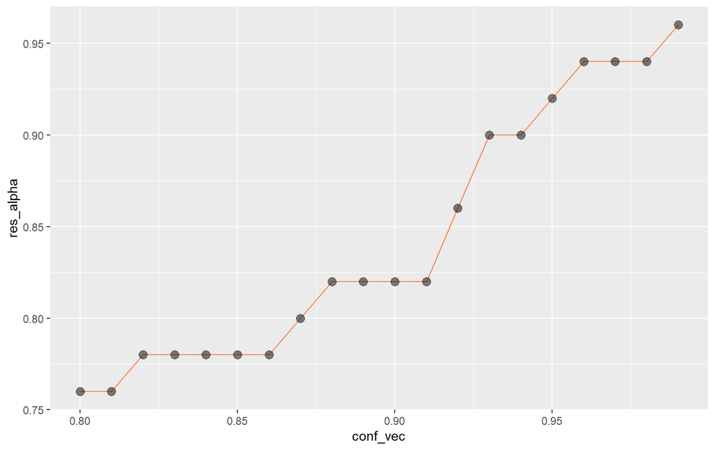

```r
ggplot() +
  geom_line(result_covertura, mapping = aes(conf_vec,res_alpha), col = "sienna1") +
  geom_point(result_covertura, mapping = aes(x=conf_vec, y=res_alpha), size=3,alpha=0.5)
```

**B.**

Simular 200 nuevos juegos de datos (de 10,40,160 y 640 observaciones cada uno) y construir diferentes intervalos de confianza con base en 500 muestras-bootstrap. Para cada tipo de intervalo de confianza, calcular el porcentaje de intervalos de confianza que no contienen el valor real $\theta$. Específicamente, si el intervalo de confianza se denota como $[\text{CI}_l, \text{CI}_u]$, calcular

- el porcentaje de veces que $\theta \notin [\text{CI}_l, \text{CI}_u]$,
- el porcentaje de veces que $\theta < \text{CI}_l$, y
- el porcentaje de veces que $\theta > \text{CI}_u$.

y mostrar los resultados en forma gráfica.

```r
# inserte acá su código
# caso para 10
r <- 200
mat_10 <- matrix(0, nrow = r, ncol = 10)

for (i in 1:r) {
  mat_10[i, ] <- rgamma(10, shape = 2, rate = 2)
}

cover10_p2 <- numeric(r)
cover10_p2_M <- numeric(r)

for (i in 1:r) {
  aux <- bootdoble_aplha(0.10, 50, 500, mat_10[i,], th)
  cover10_p2[i]<- aux[[2]]
  cover10_p2_M[i]<- aux[[3]]
}

ls_10 <- sum( cover10_p2 )/ sum(cover10_p2_M)

li_10 <- 1 - sum( cover10_p2 )/ sum(cover10_p2_M)

li_10;ls_10
```

```
## [1] 0.3426
```

```
## [1] 0.6574
```

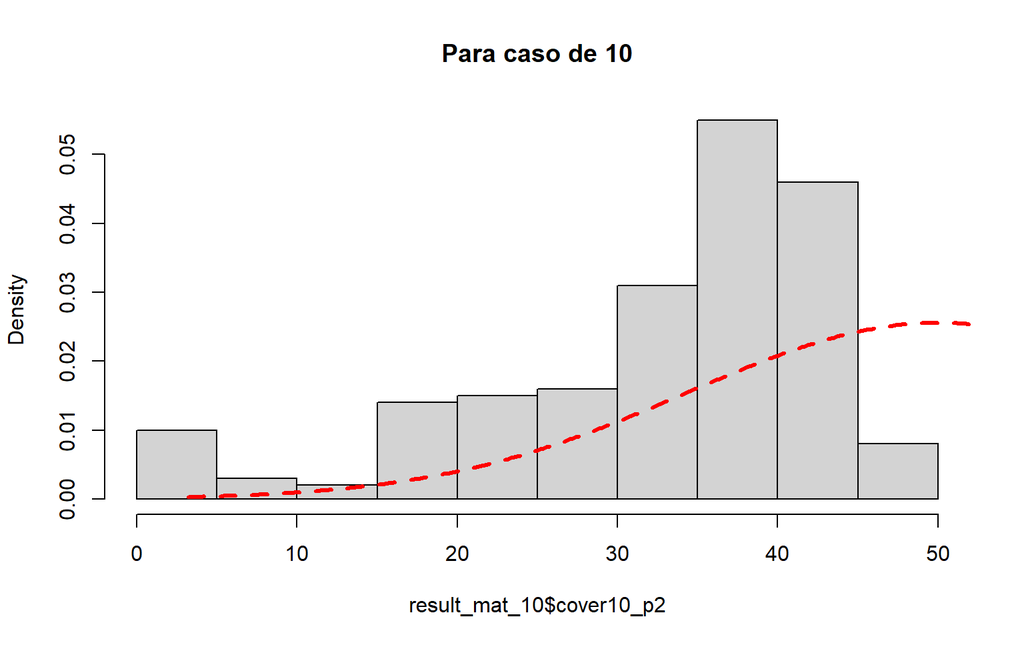

```r
result_mat_10 <- data.frame(cover10_p2, cover10_p2_M)

hist(result_mat_10$cover10_p2, xlim = c(0,50),freq = F, breaks = "FD",main = "Para caso de 10")
lines(density(result_mat_10$cover10_p2_M), col = "red", lty = 2, lwd = 3)
```

```r
# caso para 40
r <- 200
mat_40 <- matrix(0, nrow = r, ncol = 40)

for (i in 1:r) {
  mat_40[i, ] <- rgamma(40, shape = 2, rate = 2)
}

cover40_p2 <- numeric(r)
cover40_p2_M <- numeric(r)

for (i in 1:r) {
  aux <- bootdoble_aplha(0.10, 50, 500, mat_40[i,], th)
  cover40_p2[i]<- aux[[2]]
  cover40_p2_M[i]<- aux[[3]]
}

ls_40 <- sum( cover40_p2 )/ sum( cover40_p2_M )
li_40 <- 1- sum( cover40_p2 )/ sum( cover40_p2_M )

li_40;ls_40
```

```
## [1] 0.2651
```

```
## [1] 0.7349
```

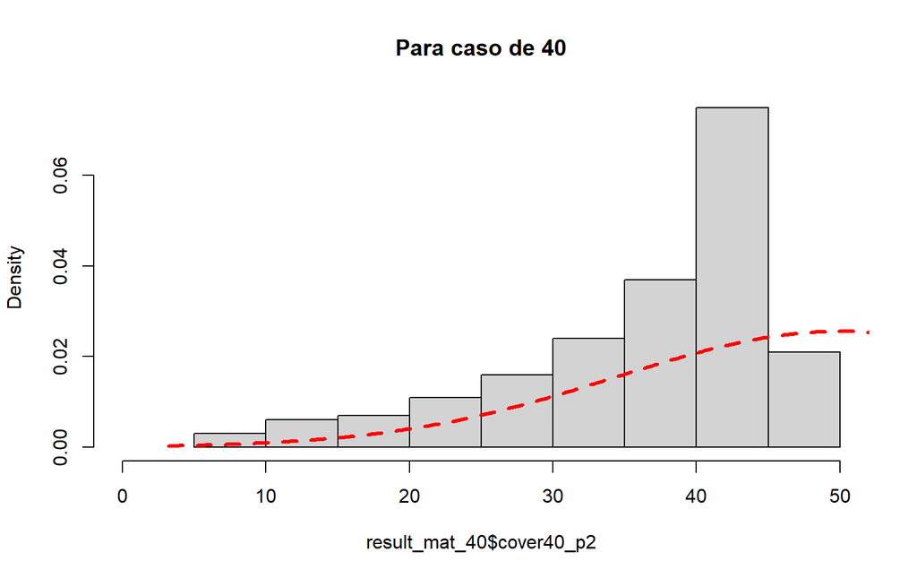

```r
result_mat_40 <- data.frame(cover40_p2, cover40_p2_M)

hist(result_mat_40$cover40_p2, xlim = c(0,50),freq = F, breaks = "FD",main = "Para caso de 40")
lines(density(result_mat_40$cover40_p2_M), col = "red", lty = 2, lwd = 3)
```

```r
# caso para 160
r <- 200
mat_160 <- matrix(0, nrow = r, ncol = 160)

for (i in 1:r) {
  mat_160[i, ] <- rgamma(160, shape = 2, rate = 2)
}

cover160_p2 <- numeric(r)
cover160_p2_M <- numeric(r)

for (i in 1:r) {
  aux <- bootdoble_aplha(0.10, 50, 500, mat_160[i,], th)
  cover160_p2[i]<- aux[[2]]
  cover160_p2_M[i]<- aux[[3]]
}

ls_160<- sum( cover160_p2 )/ sum( cover160_p2_M )
li_160<- 1- sum( cover160_p2 )/ sum( cover160_p2_M )

li_160;ls_160
```

```
## [1] 0.2316
```

```
## [1] 0.7684
```

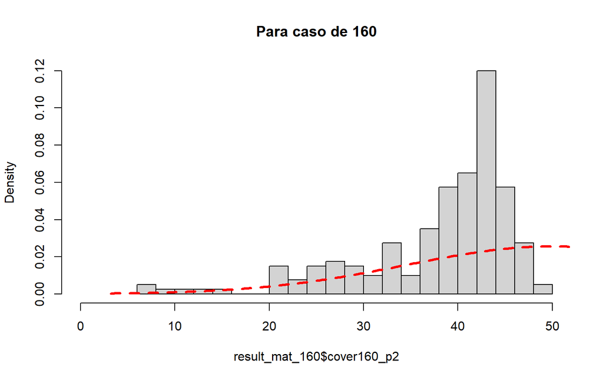

```r
result_mat_160 <- data.frame(cover160_p2, cover160_p2_M)

hist(result_mat_160$cover160_p2, xlim = c(0,50),freq = F, breaks = "FD",main = "Para caso de 160")
lines(density(result_mat_160$cover160_p2_M), col = "red", lty = 2, lwd = 3)
```

```r
# caso para 640
r <- 200
mat_640 <- matrix(0, nrow = r, ncol = 640)

for (i in 1:r) {
  mat_640[i, ] <- rgamma(640, shape = 2, rate = 2)
}

cover640_p2 <- numeric(r)
cover640_p2_M <- numeric(r)

for (i in 1:r) {
  aux <- bootdoble_aplha(0.10, 50, 500, mat_640[i,], th)
  cover640_p2[i]<- aux[[2]]
  cover640_p2_M[i]<- aux[[3]]
}

ls_640<- sum( cover640_p2 )/ sum( cover640_p2_M )
li_640<- 1- sum( cover640_p2 )/ sum( cover640_p2_M )
li_640;ls_160
```

```
## [1] 0.2592
```

```
## [1] 0.7684
```

```r
result_mat_640 <- data.frame(cover640_p2, cover640_p2_M)
```

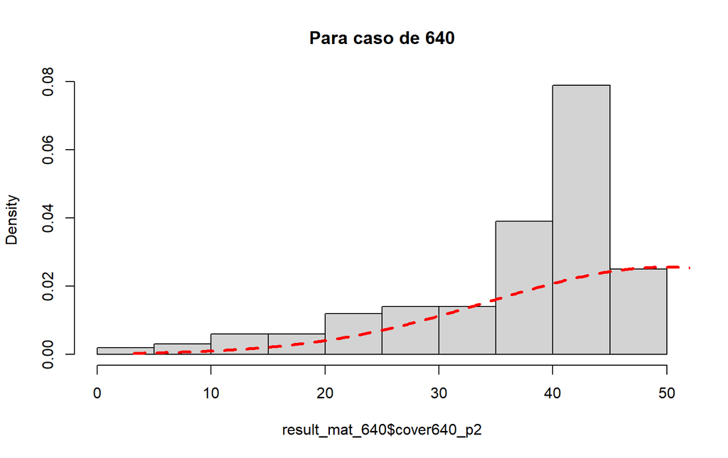

```r
hist(result_mat_640$cover640_p2, xlim = c(0,50),freq = F, breaks = "FD",main = "Para caso de 640")
lines(density(result_mat_640$cover640_p2_M), col = "red", lty = 2, lwd = 3)
```

### PREGUNTA 3: bootstrap paramétrico

En este ejercicio aplicamos bootstrap paramétrico *a mano* y lo comparamos con los resulados del paquete `boot` de R. La cantidad de interés $\theta$ es el percentil 75% de una serie de tiempos de espera $t$ (en días) para resolver un tipo de consulta en una oficina administrativa de la Universidad (durante el año 2021).

```r
t <- c(17,26,12,6,12,18,10,12,26,13,13,11,12,25,7,21,44,10,21)
```

**A.**

Ajustar los parámetros de una distribución Gamma mediante máxima verosimilitud.

**Hint:** pueden utilizar la función `fitdistr()` del paquete `MASS`.

```r
# inserte acá su código
library(MASS)
parametros <- fitdistr(t, densfun = "gamma")

x <- rgamma(t, shape = parametros$estimate[1], rate =parametros$estimate[2])
x
```

```
##  [1] 19.955304 15.447956 10.752068  7.557676 20.836424  4.684419  4.826567
##  [8] 33.920706 12.285268  7.034059 15.029228  5.320498 37.649558 22.435501
## [15]  8.923876 26.301176 25.712455 17.454666 15.583028
```

**B.**

Plotear un histograma de la variable $t$ junto con la distribución ajustada superpuesta.

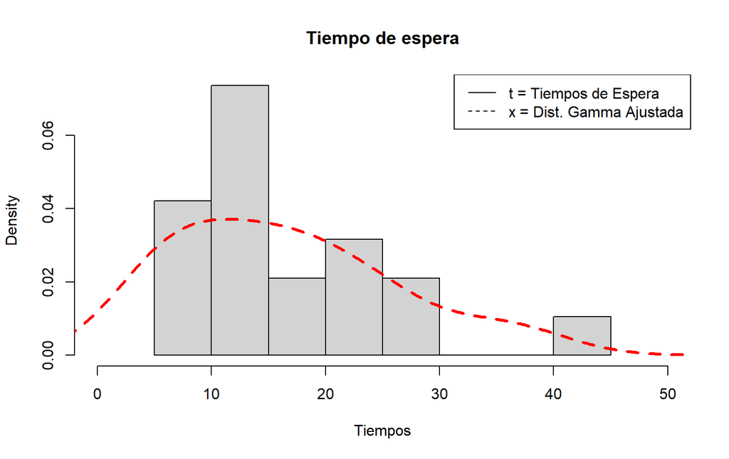

```r
# inserte acá su código
tiempos <- data.frame(t,x)

# forma 1
hist(tiempos$t, xlim = c(0,50),freq = F, breaks = "FD",main = "Tiempo de espera", xlab = "Tiempos")
lines(density(tiempos$x), col = "red", lty = 2, lwd = 3)
legend("topright", c("t = Tiempos de Espera", "x = Dist. Gamma Ajustada"), lty =1:2)
```

**C.**

Generar 1000 muestras-bootstrap utilizando bootstrap paramétrico *a mano* (sin utiliza el paquete `boot`) y estimar los correspondientes $\hat{\theta}_{n}^{*1}, \dots, \hat{\theta}_{n}^{*1000}$.

```r
# inserte acá su código
muestras <- matrix(0, nrow = 1000, ncol = 19)


for(i in 1:1000){

  muestras[i,] <- rgamma(n = 19, shape = parametros$estimate[1], rate =parametros$estimate[2] )

}

quantile_75 <- function(x) quantile(x, 0.75)

muestra_hat <- apply(muestras, 1, FUN = quantile_75)

muestra_hat
```

```
##    [1] 18.71023 20.65841 18.45906 19.81050 21.20491 19.64423 19.95985 19.50398
##    [9] 19.53671 24.64021 23.27412 21.23780 23.75666 17.16095 22.61073 21.49499
##   [17] 18.00980 17.45460 19.32934 20.73118 20.86539 24.78457 21.01758 19.61691
##   [25] 19.00593 25.00327 27.92719 28.28700 23.76303 19.04329 18.59927 21.15856
##   [33] 25.70059 19.60079 14.16310 21.38208 19.51075 21.90826 17.48435 18.12872
##   [41] 23.41641 19.98679 19.13929 25.04447 19.20550 23.95654 18.62517 14.99924
##   [49] 20.05547 24.74089 20.66385 17.42284 21.15875 17.10952 18.15971 20.26105
##   [57] 22.14531 22.91801 17.49755 24.05791 19.22463 19.41730 26.22104 24.75409
##   [65] 15.81836 19.11107 20.01912 21.85849 24.23369 24.67706 19.09381 20.10975
##   [73] 19.18959 18.16835 22.91642 20.97898 21.39994 18.76039 17.95162 16.43153
##   [81] 20.59453 22.55932 19.45339 19.64004 22.05588 24.15700 19.05972 22.23248
##   [89] 21.93509 16.89356 24.30755 27.29111 17.47071 17.39789 21.12144 17.68578
##   [97] 21.05017 19.27417 19.73372 22.76858 24.75695 21.83960 18.39278 19.25299
##  [105] 21.53243 24.44090 22.71391 20.78935 20.71645 19.18303 17.18006 16.33616
##  [113] 18.42422 20.66220 19.16922 22.37019 24.13832 18.85576 24.54864 17.95191
```

[output cut: 110 more lines]

**D.**

Construir los siugientes intervalos de confianza para $\theta$ *a mano* con base en las muestras-bootstrap (90%):

- **Cuantil:**

$$[q_{\hat{\theta^*}}(\alpha/2),q_{\hat{\theta^*}}(1-\alpha/2)]$$

- **Aproximación normal:**

$$2\hat{\theta} - \bar{\hat{\theta}^*} \pm q_{Z}(1-\alpha/2) \cdot \widehat{\text{sd}}(\hat{\theta})$$

donde $Z \sim \mathcal{N}(0,1)$ y $\widehat{\text{sd}}(\hat{\theta}) = \sqrt{\frac{1}{R-1}}\sum_{i=1}^{R}\left( \hat{\theta}^{*i}- \bar{\hat{\theta}^*} \right)^2$.

- **Cuantil inverso:**

$$[\hat{\theta}-q_{\hat{\theta}^*-\hat{\theta}}(1-\alpha/2), \hat{\theta}-q_{\hat{\theta}^*-\hat{\theta}}(\alpha/2)].$$

```r
# inserte acá su código
a <- 0.10

quantile(muestra_hat, c(a/2,1-a/2))
```

```
##       5%      95%
## 16.25852 25.36911
```

```r
# Aproximacion normal

theta_t <- quantile(t, 0.75)
theta_hat <- mean(muestra_hat)
sd <- sd(muestra_hat)
qz <- qnorm(1-a/2)

c(2*theta_t-theta_hat -qz*sd, 2*theta_t-theta_hat + qz*sd)
```

```
##      75%      75%
## 16.90318 25.95138
```

```r
# Cuantile inverso
d_theta <-muestra_hat-theta_t
quantile(d_theta, c(a/2,1-a/2))
```

```
##        5%       95%
## -4.741475  4.369105
```

```r
c(theta_t-quantile(d_theta, 1-a/2), theta_t-quantile(d_theta, a/2))
```

```
##      75%      75%
## 16.63089 25.74148
```

**E.**

Construir los mismos intervalos de confianza mediante el paquete `boot` y compararlos con los intervalos estimados en la parte **D.**.

**Hint:** utilice `boot(..., sim="parametric", ran.gen = ..., mle = ...)`. Revise la ayuda de la función `boot` para más detalles.

```r
# inserte acá su código
library(boot)

t.func <- function(data) quantile(data, 0.75)
t.rg <- function(data, mle) {
  est <- rgamma(length(data),shape = mle[[1]] , rate = mle[[2]] )
  est }
log_sum <- sum(t*log(t))

usando_boot = boot(data=t, statistic =  t.func, sim="parametric",
                  ran.gen=t.rg , mle = parametros$estimate  , R=1000)


# IC Cuantil
boot.ci (usando_boot , type="perc", conf = 0.90)
```

```
## BOOTSTRAP CONFIDENCE INTERVAL CALCULATIONS
## Based on 1000 bootstrap replicates
##
## CALL :
## boot.ci(boot.out = usando_boot, conf = 0.9, type = "perc")
##
## Intervals :
## Level     Percentile
## 90%   (16.65, 25.79 )
## Calculations and Intervals on Original Scale
```

```r
# IC Normal
boot.ci (usando_boot , type="norm", conf = 0.90)
```

```
## BOOTSTRAP CONFIDENCE INTERVAL CALCULATIONS
## Based on 1000 bootstrap replicates
##
## CALL :
## boot.ci(boot.out = usando_boot, conf = 0.9, type = "norm")
##
## Intervals :
## Level      Normal
## 90%   (16.59, 25.73 )
## Calculations and Intervals on Original Scale
```

```r
# IC inverso
boot.ci (usando_boot , type="basic", conf = 0.90)
```

```
## BOOTSTRAP CONFIDENCE INTERVAL CALCULATIONS
## Based on 1000 bootstrap replicates
##
## CALL :
## boot.ci(boot.out = usando_boot, conf = 0.9, type = "basic")
##
## Intervals :
## Level      Basic
## 90%   (16.21, 25.35 )
## Calculations and Intervals on Original Scale
```